# CEM Results

Skip Moses (+Robin)

4/3/2022

## Summary

This is a document for Coarsened Exact Matching results.

## BIO104

Note from Robin:

- This is not only BIO 104. All courses are present
- Also, this is not only FTF. Consider filtering.
- Matching is still done on the full dataset, not the intersections of URM & FG. That means students from diff demographics are being matched.

```r
# 2017 Student grades/SI/demographic data
data <- read.csv("data/CEM_dataset.csv")
#data <- read.csv("C:/Box/Projects_Current/SI Equity analysis/data/CEM_dataset.csv")

data.fall <- data %>% filter(Term.Type == "Fall") %>%
  select(-X) %>%
  # Remove Withdraws from class
  filter(Student.Class.Grade.Point.per.Unit > 0)

# COnvert to factors
data.fall$SI.Attended <- as.factor(data.fall$SI.Attended)
data.fall$Random.Student.ID <- as.factor(data.fall$Random.Student.ID)
data.fall$Random.Course.ID <- as.factor(data.fall$Random.Course.ID)

# Center the grade per unit (this is actually normalizing - RAD)
# And it's normalizing against the mean/sd for the entire data set.
# normalizing within class would be more appropriate.
# (IF we really need to go there. let's keep the normal grade scale for now.)
#data.fall$Grade.Point.per.Unit.center <- (data.fall$Student.Class.Grade.Point.per.Unit - mean(data.fall$Student.Class.Grade.Point.per.Unit))/sd(data.fall$Student.Class.Grade.Point.per.Unit)
```

```r
# Turning this off to to calculate glm derived propensity
# Estimate Propensity Scores
prop.score <- glm(SI.Attended ~ HS.GPA +
                    Student.Orientation.Flag +
                    Major.1.STEM.Flag +
                    Random.Course.ID, family = binomial, data = data.fall)

summary(prop.score)
```

```
##
## Call:
## glm(formula = SI.Attended ~ HS.GPA + Student.Orientation.Flag +
##     Major.1.STEM.Flag + Random.Course.ID, family = binomial,
##     data = data.fall)
##
## Deviance Residuals:
##     Min       1Q   Median       3Q      Max
## -2.5593  -0.9820   0.6746   0.8392   1.6309
##
## Coefficients:
##                             Estimate Std. Error z value Pr(>|z|)
## (Intercept)                4.366e-01  6.397e-01   0.682   0.4949
## HS.GPA                     2.812e-01  1.705e-01   1.649   0.0991 .
## Student.Orientation.FlagY  8.898e-03  1.439e-01   0.062   0.9507
## Major.1.STEM.FlagY        -2.793e-01  1.799e-01  -1.552   0.1207
## Random.Course.ID7490      -7.980e-01  3.296e-01  -2.421   0.0155 *
## Random.Course.ID10788     -1.304e+00  3.341e-01  -3.903 9.49e-05 ***
## Random.Course.ID10792     -1.750e-01  3.610e-01  -0.485   0.6278
## Random.Course.ID10796     -7.345e-01  4.418e-01  -1.662   0.0964 .
## Random.Course.ID11676      7.624e-02  6.145e-01   0.124   0.9013
## Random.Course.ID11783     -6.809e-01  4.040e-01  -1.686   0.0919 .
## Random.Course.ID14054     -2.880e-01  2.955e-01  -0.975   0.3297
## Random.Course.ID15755     -1.819e+00  4.099e-01  -4.437 9.11e-06 ***
## Random.Course.ID17755     -1.990e+00  3.765e-01  -5.286 1.25e-07 ***
## Random.Course.ID18895     -4.936e-01  4.217e-01  -1.170   0.2418
## Random.Course.ID19927      1.631e+01  8.369e+02   0.019   0.9844
## Random.Course.ID19928      1.628e+01  8.224e+02   0.020   0.9842
## Random.Course.ID19929      1.867e+00  1.059e+00   1.763   0.0780 .
## Random.Course.ID21179     -5.288e-01  3.239e-01  -1.633   0.1025
## Random.Course.ID22431      1.630e+01  8.050e+02   0.020   0.9838
## Random.Course.ID22432      1.905e+00  1.061e+00   1.795   0.0726 .
## Random.Course.ID22433      1.905e+00  1.060e+00   1.797   0.0723 .
## Random.Course.ID22599     -1.866e+00  4.651e-01  -4.012 6.03e-05 ***
## Random.Course.ID22824      1.639e+01  2.765e+03   0.006   0.9953
## Random.Course.ID23124     -6.663e-01  5.507e-01  -1.210   0.2264
## Random.Course.ID25606     -8.762e-01  6.536e-01  -1.341   0.1800
## Random.Course.ID265067     2.880e-01  6.186e-01   0.466   0.6415
## Random.Course.ID265068     1.173e+00  7.912e-01   1.483   0.1382
## ---
## Signif. codes:  0 '***' 0.001 '**' 0.01 '*' 0.05 '.' 0.1 ' ' 1
##
## (Dispersion parameter for binomial family taken to be 1)
##
##     Null deviance: 1584.8  on 1268  degrees of freedom
## Residual deviance: 1370.1  on 1242  degrees of freedom
## AIC: 1424.1
##
## Number of Fisher Scoring iterations: 16
```

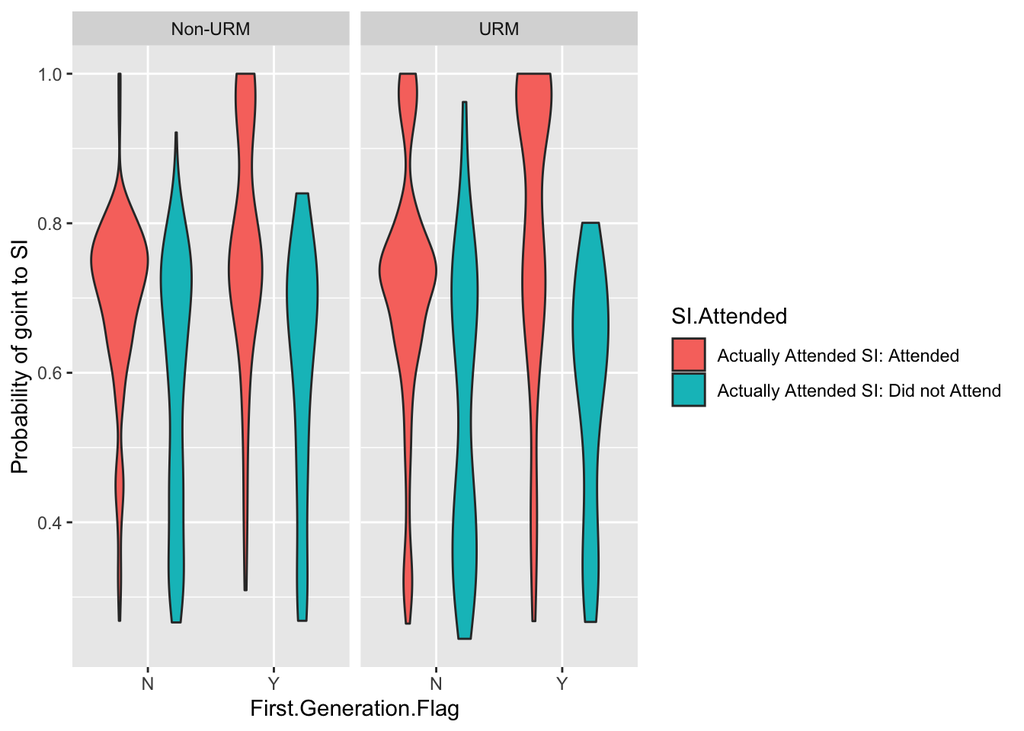

```r
data.fall$Prop.Score <- predict(prop.score, type = "response")

labs <- paste("Actually Attended SI:", c("Did not Attend", "Attended"))

# Histogram of Propensity Scores (I think the labels are reversed)
#data.fall %>% mutate(SI.Attended = ifelse(SI.Attended == 1, labs[1], labs[2])) %>%
#  ggplot(aes(x = Prop.Score)) +
#    geom_histogram(binwidth = .1) + facet_wrap(~SI.Attended) + xlab("Probability of goint to SI")

data.fall %>% mutate(SI.Attended = ifelse(SI.Attended == 1, labs[2], labs[1])) %>%
  ggplot(aes(x = Prop.Score, y=First.Generation.Flag, fill=SI.Attended)) +
    geom_violin() +
  facet_wrap(~IPEDS.Ethnicity.URM.Non.URM) + coord_flip()+
  xlab("Probability of goint to SI")
```

```r
# Here we make our matching. The k2K = TRUE will coarsen the covariates first
# and then do an exact matching on the coarsend data. This allows us to compute
# the difference in grade between our matching.
matching <- matchit(SI.Attended ~
                      HS.GPA +
                      Student.Orientation.Flag +
                      Major.1.STEM.Flag +
                      Random.Course.ID ,
                    data = data.fall,
                    method = 'cem', estimand = 'ATE',
                    k2k = TRUE, # After Pair Matching without Replacement
                    k2k.method = "euclidean")
matching
```

```
## A matchit object
##  - method: Coarsened exact matching
##  - number of obs.: 1269 (original), 498 (matched)
##  - target estimand: ATE
##  - covariates: HS.GPA, Student.Orientation.Flag, Major.1.STEM.Flag, Random.Course.ID
```

```r
#summary(matching)
```

Skip: Need to discuss quality of matches.

- The average treatment effect in the population (ATE) is the average effect of the treatment **for all units in the target population**.
- The average treatment effect in the treated (ATT) is the average effect of the treatment for units **like those who actually were treated**.

```r
# Covariates should be those that cause variation in the outcome and selection into treatment group; these are known as confounding variables. (Greifer)
matching.strict <- matchit(SI.Attended ~
                      HS.GPA +
                      Student.Orientation.Flag +
                      Major.1.STEM.Flag +
                      Random.Course.ID +
                      Academic.Level +
                      First.Generation.Flag +
                      IPEDS.Ethnicity.URM.Non.URM +
                      Gender.Code,
                    data = data.fall,
                    method = 'cem', estimand = 'ATT',
                    k2k = TRUE, # FALSE - After Stratum Matching
                    k2k.method = "euclidean")
matching.strict
```

```
## A matchit object
##  - method: Coarsened exact matching
##  - number of obs.: 1269 (original), 112 (matched)
##  - target estimand: ATT
##  - covariates: HS.GPA, Student.Orientation.Flag, Major.1.STEM.Flag, Random.Course.ID, Academic.Level, First.Generation.Flag, IPEDS.Ethnicity.URM.Non.URM, Gender.Code
```

```r
# Extract Matched pairs
matched_df1 <- match.data(matching) %>%
  relocate(subclass, SI.Attended) %>%
  arrange(subclass, SI.Attended)  %>%
  rename(grade = Student.Class.Grade.Point.per.Unit)
```

## Exploratory plots with matched sample - trying to create this gap

```r
# Identify courses with 20 or more students (10 matched pairs per class)
matched_courses <- matched_df1 %>% group_by(Random.Course.ID) %>%
  tally() %>% filter(n>=20) %>% droplevels()

matched_df2 <- matched_df1 %>%
  filter(Random.Course.ID %in% matched_courses$Random.Course.ID) %>%
  group_by(Random.Course.ID, First.Generation.Flag, SI.Attended) %>%
  summarise(avg.grade = mean(grade),
            n=n())
```

```
## You can override using the `.groups` argument.
```

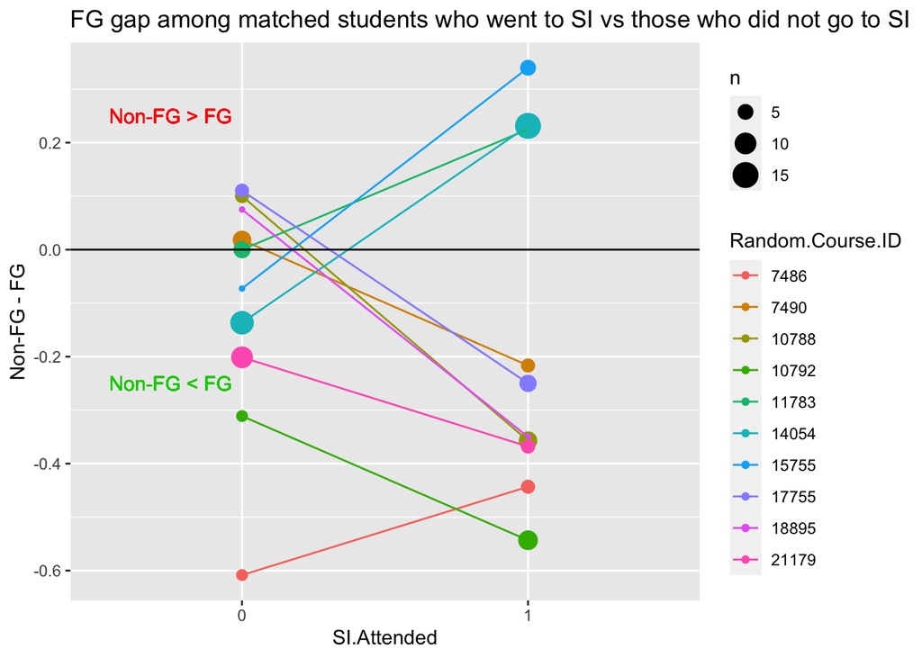

```r
matched_df2_wide <- matched_df2 %>%
  pivot_wider(id_cols = c(Random.Course.ID, SI.Attended),
              names_from = First.Generation.Flag,
              values_from = c(avg.grade, n)) %>%
  mutate(fg_gap = avg.grade_N - avg.grade_Y,
         n = pmin(n_N, n_Y))

ggplot(matched_df2_wide,
       aes(y=fg_gap, x=SI.Attended, color = Random.Course.ID,
           group = Random.Course.ID)) +
  geom_point(aes(size=n)) + geom_line()  + geom_hline(yintercept=0) +
  geom_text(aes(x=.75, y=.25, label = "Non-FG > FG"), col="red") +
  geom_text(aes(x=.75, y=-.25, label = "Non-FG < FG"), col="green3") +
  ylab("Non-FG - FG") +
  ggtitle("FG gap among matched students who went to SI vs those who did not go to SI")
```

- At the course-section level - possibly too small sample sizes here. Sometimes within a class, only 2 students who are a FG who didn’t go to SI. We also didn’t match on FG.
- Size of dots is the min size of either FG or NonFG.

```r
matched_df2[33:40,]
```

```
## # A tibble: 8 × 5
## # Groups:   Random.Course.ID, First.Generation.Flag [4]
##   Random.Course.ID First.Generation.Flag SI.Attended avg.grade     n
##   <fct>            <fct>                 <fct>           <dbl> <int>
## 1 18895            N                     0                2.42     8
## 2 18895            N                     1                2.3      8
## 3 18895            Y                     0                2.35     2
## 4 18895            Y                     1                2.65     2
## 5 21179            N                     0                2.11    23
## 6 21179            N                     1                2.81    29
## 7 21179            Y                     0                2.31    10
## 8 21179            Y                     1                3.18     4
```

### Overall (not course level) gap

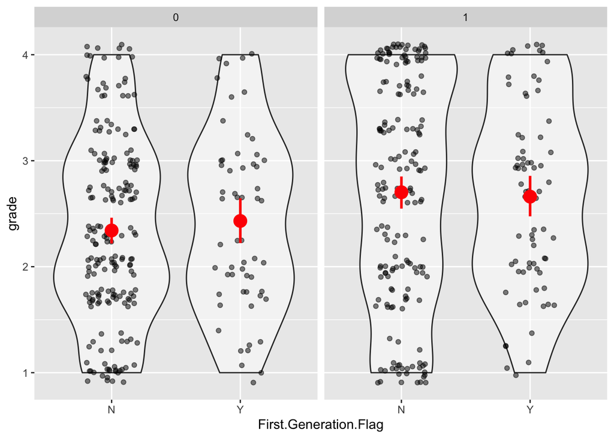

```r
ggplot(matched_df1, aes(y=grade, x = First.Generation.Flag)) +
  geom_violin(alpha=.5) + geom_jitter(alpha=.5, width=.2, height=.1) +
   stat_summary(fun.data = "mean_cl_boot", colour = "red", size = 1) +
  facet_wrap(~SI.Attended)
```

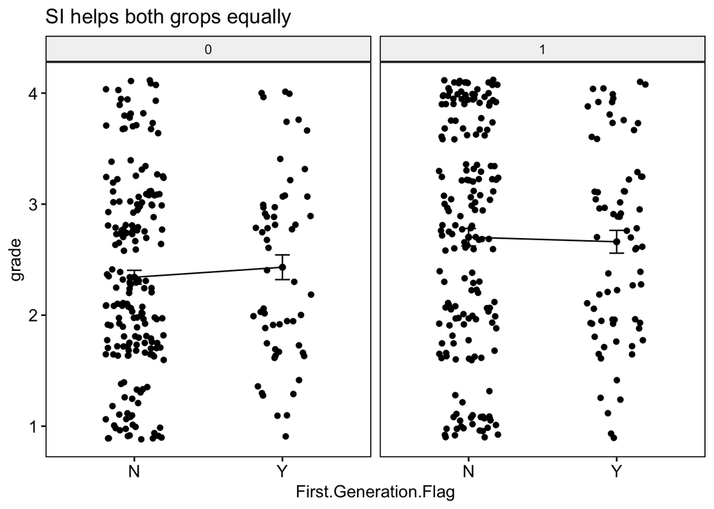

```r
matched_df1 %>% ggline(x="First.Generation.Flag", y = "grade",
                       facet.by = "SI.Attended", add=c("jitter", "mean_se")) +
  ggtitle("SI helps both grops equally")
```

### Assess treatment affect on matched sample

```r
# Following https://cloud.r-project.org/web/packages/MatchIt/vignettes/MatchIt.html
fit1 <- lm(grade ~ SI.Attended + HS.GPA + Student.Orientation.Flag + Academic.Level +
     Major.1.STEM.Flag + First.Generation.Flag + IPEDS.Ethnicity.URM.Non.URM +
     Gender.Code,
   data=matched_df1, weights = weights)

coeftest(fit1, vcov. = vcovCL, cluster = ~subclass)
```

```
##
## t test of coefficients:
##
##                                 Estimate Std. Error t value  Pr(>|t|)
## (Intercept)                     0.085277   0.410826  0.2076 0.8356488
## SI.Attended1                    0.377702   0.075521  5.0013 7.964e-07 ***
## HS.GPA                          0.728460   0.114791  6.3460 5.061e-10 ***
## Student.Orientation.FlagY      -0.011197   0.078879 -0.1419 0.8871787
## Academic.LevelJunior            0.077665   0.114340  0.6792 0.4973057
## Academic.LevelSenior           -0.065520   0.114209 -0.5737 0.5664472
## Academic.LevelSophomore         0.043306   0.095632  0.4528 0.6508698
## Major.1.STEM.FlagY             -0.441346   0.076851 -5.7428 1.641e-08 ***
## First.Generation.FlagY          0.032037   0.082125  0.3901 0.6966343
## IPEDS.Ethnicity.URM.Non.URMURM -0.286430   0.082050 -3.4909 0.0005251 ***
## Gender.CodeM                    0.119794   0.077437  1.5470 0.1225153
## ---
## Signif. codes:  0 '***' 0.001 '**' 0.01 '*' 0.05 '.' 0.1 ' ' 1
```

```r
# it is important not to interpret the coefficients and tests of the other covariates in the outcome model. These are not causal effects and their estimates may be severely confounded.
```

The estimated effect was (0.377, SE=.076, p<.0001), indicating that the average effect of attending SI 0.37 grade points higher compared to those that did not go to SI in 2017.

Results still pending further filtering such as on FTF only. And possibly including more years.

### Strict matching

```r
matched_df1.strict <- match.data(matching.strict) %>%
  rename(grade = Student.Class.Grade.Point.per.Unit)

fit.strict <- lm(grade ~ SI.Attended + HS.GPA + Student.Orientation.Flag + Academic.Level +
     Major.1.STEM.Flag + First.Generation.Flag + IPEDS.Ethnicity.URM.Non.URM +
     Gender.Code,
   data=matched_df1.strict, weights = weights)

coeftest(fit.strict, vcov. = vcovCL, cluster = ~subclass)
```

```
##
## t test of coefficients:
##
##                                 Estimate Std. Error t value  Pr(>|t|)
## (Intercept)                     0.076379   1.144112  0.0668   0.94691
## SI.Attended1                    0.812500   0.151189  5.3741 4.963e-07 ***
## HS.GPA                          0.669825   0.317875  2.1072   0.03758 *
## Student.Orientation.FlagY      -0.149510   0.172091 -0.8688   0.38702
## Academic.LevelJunior           -0.044822   0.305108 -0.1469   0.88350
## Academic.LevelSenior            0.106963   0.212879  0.5025   0.61644
## Academic.LevelSophomore        -0.097970   0.235620 -0.4158   0.67844
## Major.1.STEM.FlagY             -0.444264   0.186339 -2.3842   0.01898 *
## First.Generation.FlagY          0.024288   0.297334  0.0817   0.93506
## IPEDS.Ethnicity.URM.Non.URMURM -0.061584   0.266525 -0.2311   0.81773
## Gender.CodeM                    0.239313   0.177980  1.3446   0.18176
## ---
## Signif. codes:  0 '***' 0.001 '**' 0.01 '*' 0.05 '.' 0.1 ' ' 1
```

- Hoooooly hell. A near full grade point higher? Too good to be true. What am I missing??

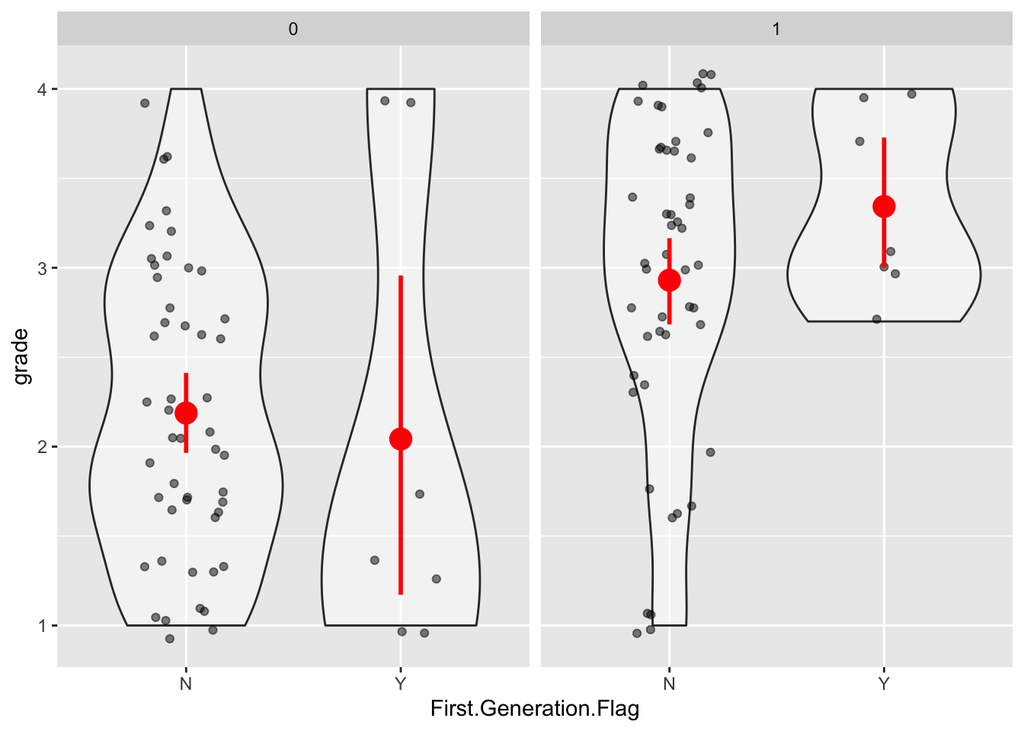

```r
ggplot(matched_df1.strict, aes(y=grade, x = First.Generation.Flag)) +
  geom_violin(alpha=.5) + geom_jitter(alpha=.5, width=.2, height=.1) +
   stat_summary(fun.data = "mean_cl_boot", colour = "red", size = 1) +
  facet_wrap(~SI.Attended)
```

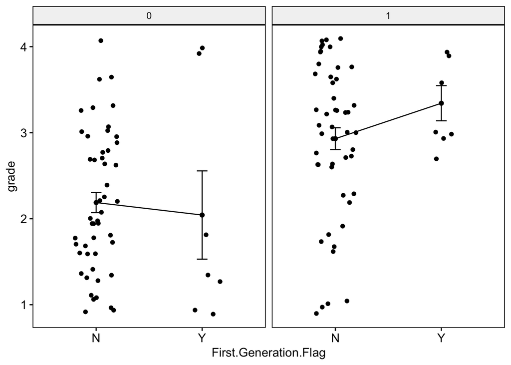

```r
matched_df1.strict %>% ggline(x="First.Generation.Flag", y = "grade",
                       facet.by = "SI.Attended", add=c("jitter", "mean_se"))
```

So few FG people?

```r
table(matched_df1.strict$SI.Attended, matched_df1.strict$First.Generation.Flag)
```

```
##
##      N  Y
##   0 49  7
##   1 49  7
```

What about URM?

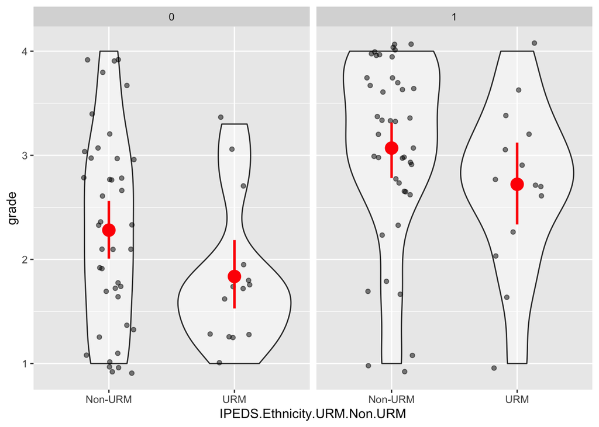

```r
ggplot(matched_df1.strict, aes(y=grade, x = IPEDS.Ethnicity.URM.Non.URM)) +
  geom_violin(alpha=.5) + geom_jitter(alpha=.5, width=.2, height=.1) +
   stat_summary(fun.data = "mean_cl_boot", colour = "red", size = 1) +
  facet_wrap(~SI.Attended)
```

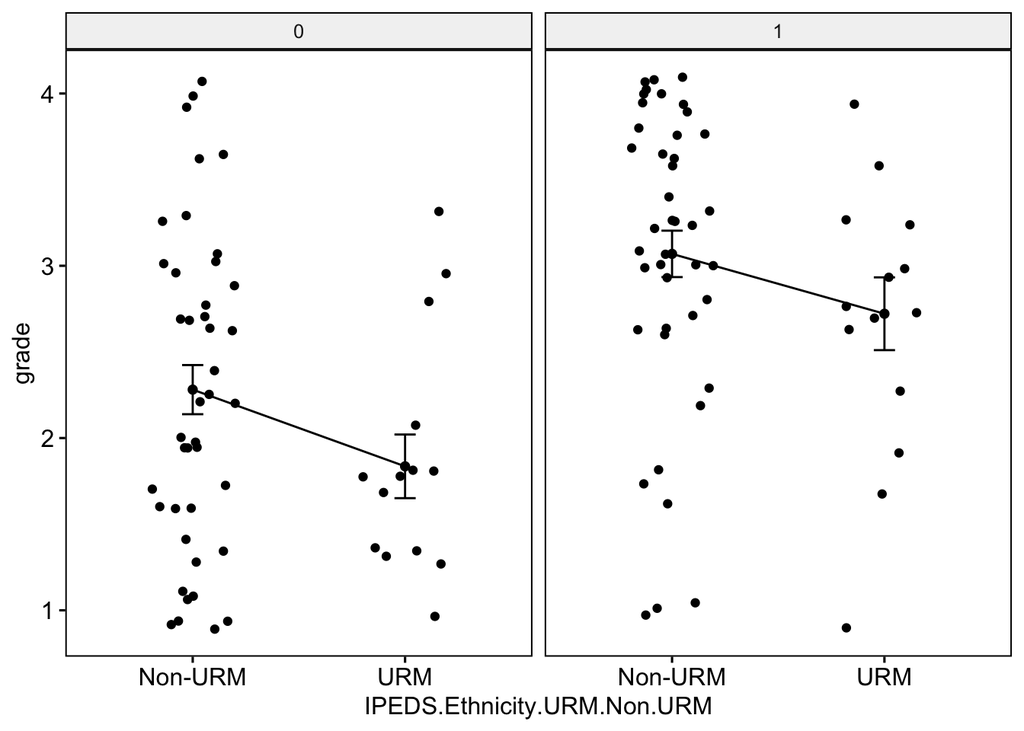

```r
matched_df1.strict %>% ggline(x="IPEDS.Ethnicity.URM.Non.URM", y = "grade",
                       facet.by = "SI.Attended", add=c("jitter", "mean_se"))
```

```r
table(matched_df1.strict$SI.Attended, matched_df1.strict$IPEDS.Ethnicity.URM.Non.URM)
```

```
##
##     Non-URM URM
##   0      42  14
##   1      42  14
```

what is the unmodified gap within SI?

```r
matched_df1.strict %>% filter(SI.Attended==1) %>%
  t.test(grade~IPEDS.Ethnicity.URM.Non.URM, data=.)
```

```
##
##  Welch Two Sample t-test
##
## data:  grade by IPEDS.Ethnicity.URM.Non.URM
## t = 1.3872, df = 24.446, p-value = 0.1779
## alternative hypothesis: true difference in means is not equal to 0
## 95 percent confidence interval:
##  -0.1690684  0.8643065
## sample estimates:
## mean in group Non-URM     mean in group URM
##              3.069048              2.721429
```

```r
matched_df1.strict %>% filter(SI.Attended==0) %>%
  t.test(grade~IPEDS.Ethnicity.URM.Non.URM, data=.)
```

```
##
##  Welch Two Sample t-test
##
## data:  grade by IPEDS.Ethnicity.URM.Non.URM
## t = 1.9073, df = 29.777, p-value = 0.06617
## alternative hypothesis: true difference in means is not equal to 0
## 95 percent confidence interval:
##  -0.03166481  0.92214100
## sample estimates:
## mean in group Non-URM     mean in group URM
##              2.280952              1.835714
```

> Don’t get excited yet Erik! We MUST consult someone who is an expert in causal modeling to confirm that we didn’t mess up and/or interpreting this right.